# Final Project US Overview Portion

Anders Lie

4/25/2021

```r
library(tidyverse)
library(rmarkdown)
library(lubridate)
```

# Overview of U.S. Motor Accidents

Before we dive into the specific features of crashes and possible mitigations, we first take a look at the 4.2 million record accident dataset as a whole.

The dataset spans from 2016 to 2020. We first process the data into a form that allows us to summarize some aspects of it more easily.

We also use a chart to convert the state abbreviations to state names as well as a dataset contains census population counts.

```r
#acc_raw <- read_csv('US_Accidents_Dec20.csv')

# TEMP
acc_raw <- read_csv('US_Accidents_Sample.csv')

census_raw <- read.csv('census2010-2019.csv')
states <- map_data('state')
abv <- read.csv('state_abbrvs.csv', fileEncoding="UTF-8-BOM")


# === Census Preprocessing ===
# Separate area into city and state, summarize population per state in each year
census <- census_raw %>%
  mutate(across(Census:X2019, function(x){as.numeric(gsub(",", "", x))})) %>%
  separate(Geographic.Area, sep=', ', into=c('City', 'region')) %>%
  group_by(region) %>%
  summarize(
    `2016`=sum(X2016),
    `2017`=sum(X2017),
    `2018`=sum(X2018),
    `2019`=sum(X2019)
  ) %>%
  pivot_longer(`2016`:`2019`, names_to='Year', values_to='Population') %>%
  mutate(Year=as.numeric(Year), State=region) %>%
  select(-region)


# === Accidents Preprocssing ===
# Convert state code to state name, format time, select only the columns needed
acc <- acc_raw %>%
  mutate(Code=State) %>%
  select(-State) %>%
  left_join(abv, by='Code') %>%
  select(Start_Time, Start_Lat, Start_Lng, State) %>%
  mutate(State=tolower(State), Time=ymd_hms(Start_Time)) %>%
  select(-Start_Time) %>%
  mutate(State=str_to_title(State))

states <- states %>%
  mutate(State=str_to_title(region)) %>%
  select(-region, -subregion)
```

First, we can visualize the accidents all over the U.S. by plotting them as points over a map of the U.S.

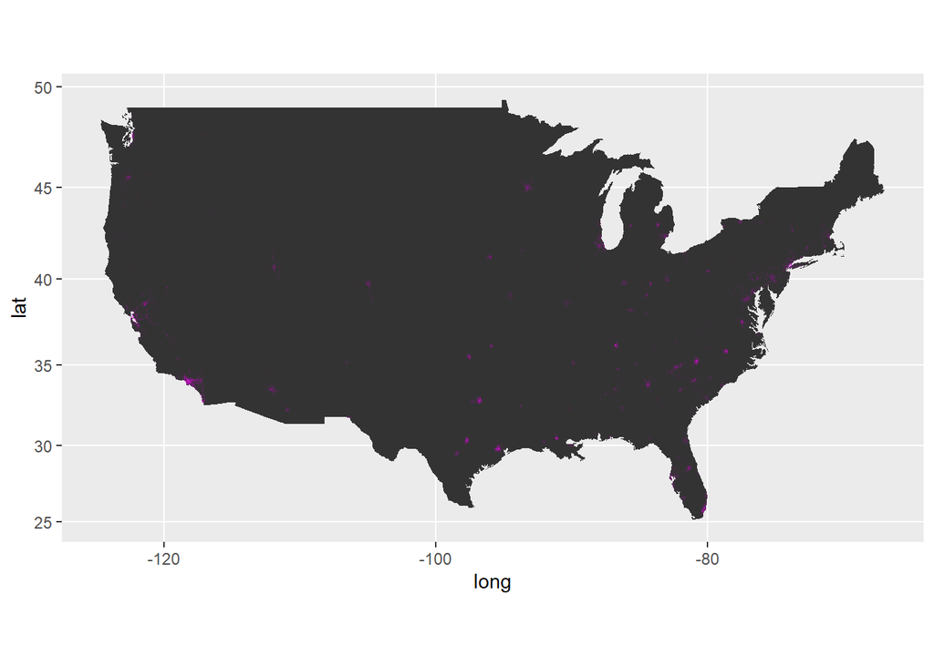

```r
states %>% ggplot(aes(x=long, y=lat)) +
  geom_polygon(aes(group=group)) +
  geom_point(data=acc, aes(x=Start_Lng, y=Start_Lat), color='magenta2', size=0.02, alpha=0.02) +
  coord_map()
```

We can see that accidents are concentrated in cities and also on roads, since of course those are locations where cars drive the most, and therefore where accidents are most likely to occur.

However, we may want to instead see the total accidents by state. We can do so using a choropleth map.

Below is a choropleth map showing the total accidents over 2016-2020 by state.

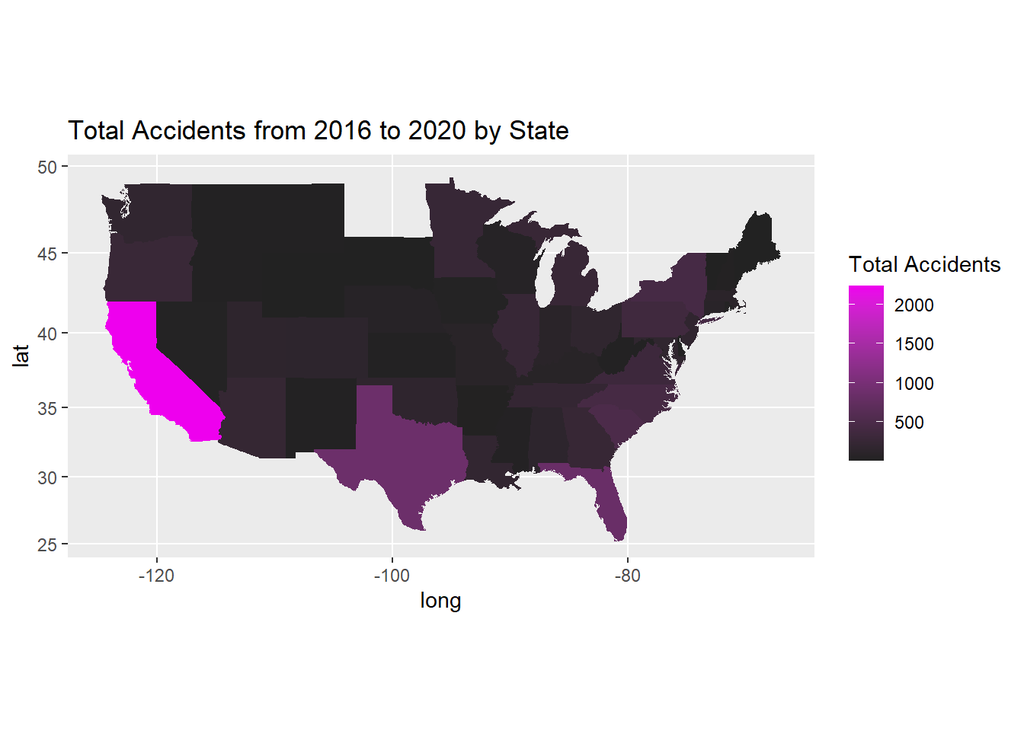

```r
acc_states <- acc %>% group_by(State) %>% summarize(total_accidents=n())

acc_map <- acc_states %>% left_join(states, by='State')

ggplot(acc_map, aes(x=long, y=lat)) +
  geom_polygon(aes(group=group, fill=total_accidents)) +
  coord_map() + labs(fill='Total Accidents') +
  scale_fill_gradient(low="#222222", high="magenta2") +
  ggtitle('Total Accidents from 2016 to 2020 by State')
```

Above we can see that clearly the states with the highest populations (California, Texas, Florida) have the most accidents total, which makes sense. It might be more insightful to instead look at the per capita accident rates.

```r
acc2019 <- acc %>% filter(year(Time)==2019)

census2019 <- census %>% filter(Year==2019)

acc2019 <- acc2019 %>% left_join(census2019, by='State')

acc2019_states <- acc2019 %>%
  group_by(State) %>%
  summarize(total_accidents=n(), population=first(Population), per1000=n()*1000/first(Population))

acc2019_states %>% paged_table
```

|  | State | total_accidents | population | per1000 |
| --- | --- | --- | --- | --- |
| 1 | Alabama | 40 | 2998987 | 0.0133378371 |
| 2 | Arizona | 78 | 5791407 | 0.0134682297 |
| 3 | California | 545 | 32965607 | 0.0165323818 |
| 4 | Colorado | 49 | 4279051 | 0.0114511372 |
| 5 | Connecticut | 15 | 1379443 | 0.0108739542 |
| 6 | Delaware | 4 | 276116 | 0.0144866650 |
| 7 | District Of Columbia | 5 | NA | NA |
| 8 | Florida | 140 | 10766975 | 0.0130027236 |
| 9 | Georgia | 49 | 4685332 | 0.0104581703 |
| 10 | Idaho | 2 | 1257628 | 0.0015902954 |

[output cut: 34 more lines]

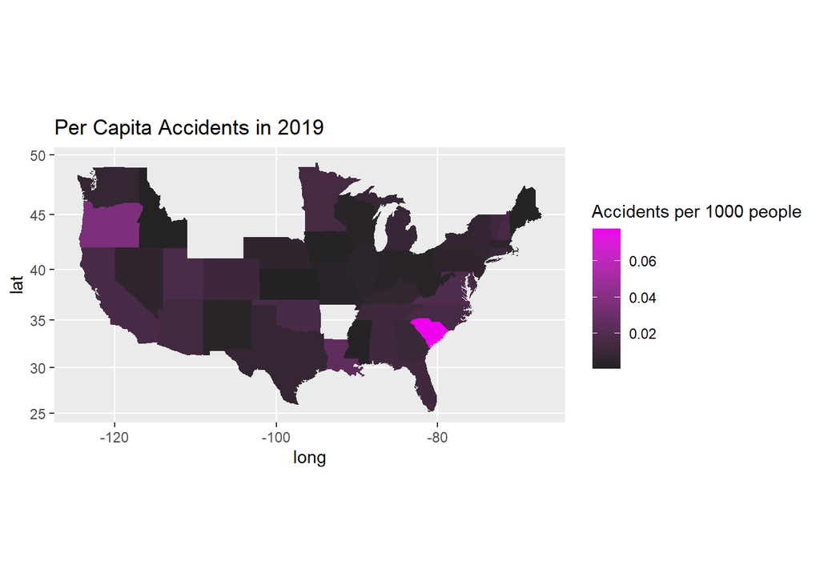

```r
acc_map_capita <- acc2019_states %>% left_join(states, by=c('State'))

ggplot(acc_map_capita, aes(x=long, y=lat)) +
  geom_polygon(aes(group=group, fill=per1000)) +
  coord_map() + ggtitle('Per Capita Accidents in 2019') +
  labs(fill='Accidents per 1000 people') +
  scale_fill_gradient(low="#222222", high="magenta2")
```

Interestingly, we can see that South Carolina and Oregon seem to have the highest per capita accident rates.

We can further investigate this with the use of a bar chart.

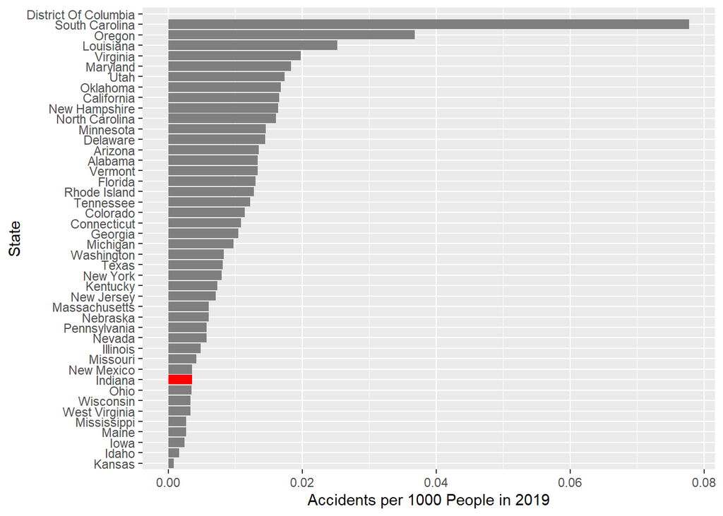

```r
col <- c(rep(c('grey50'), 8), c('red'), rep(c('grey50'), 40))

acc2019_states %>%
  mutate(State=str_to_title(State)) %>%
  arrange(per1000) %>%
  mutate(State=factor(State, levels=State)) %>%
  ggplot(aes(x=State, weight=per1000, fill=State)) + geom_bar() + coord_flip() +
  scale_fill_manual(values=col) +
  ylab('Accidents per 1000 People in 2019') +
  theme(legend.position = "none")
```

We can see that South Carolina has approximately double the accident rate of Oregon.

It’s difficult to attribute this to some cause. It could be some problem with South Carolina’s infrastructure or driving education but that lies outside the scope of this project.